# **Un exemple de système chaotique**

## **La population de lapins**

On suppose que le systeme suivant decrit correctement une populations de lapins. Soit *n<sub>i</sub>* le noubre de lapins à l'année *i* et *$\alpha$* le nombre de petits par an par individus. Ainsi à l'année *i+1* on a:
$$n_i+1 = \alpha * n_i$$

Si *$\alpha$* est constant alors on a :
$$n_i= \alpha^i * n_initial$$

ce qui correspond a une croissance exponentielle de la populations de lapins.

Or la quantité limité de ressources ainsi que la presence de prédateurs limite cette croissance, cela va alors se tradiore par un *$\alpha$* sous forme de fonction de *n<sub>i</sub>*. Si on nore *r* le taux de croissance maximal et *n<sub>max</sub>* le nombre maximal de lapins qu’il peut exister, alors *$\alpha$* pourrait s’écrire:
$$\alpha = r \left( 1 - \frac{n_i}{n_{\max}} \right)$$

La forme de l'équation d'évolution de la population devient alors

$$ n_{i+1} = r \left( 1 - \frac{n_i}{n_{\max}} \right) n_i $$

et peut se réécrire avec une nouvelle variable $x_i = n_i / n_{\max}$

$$ x_{i+1} = r (1-x_i)x_i $$

que l'on appelle « l'équation logistique ».

Pour l'étude de cette équation, on introduit la fonction

$$ f(x) = r (1-x) x $$

dont le seul paramètre est $r$, et dont la valeur influence le comportement de la suite

$$ x_{i+1} = f(x_i) $$

qui se trouve être chaotique. $r$ doit être compris entre 1 et 4.

#### Nous allons donc etudier le comportement de cette suite

### **Comportement de la suite a r constant**

```
0.5999981216054902 0.6000009391884339
```

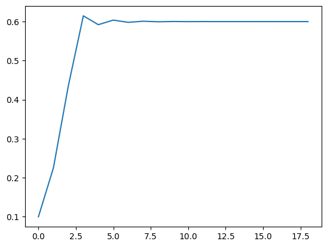

```python
#importation des bibliothèques
import numpy as np
import matplotlib.pyplot as plt

N = 18
r = 2.5

def function(X):
    j = np.arange(0, X+1, 1)     #création d'un lableau d'entier allant de 0 à N
    x =[0.1]                     #on créé le tableau x en t metant la valeur x0
    for i in range (X):
        x.append(r*(1-x[i])*x[i])
    print(x[N-2], x[N-1])
    plt.plot(j, x)


function(N)
```

On constate que avec un r=2.5 la suite tend rapidement vers 0.6

On peut alors essayer avec d'autres valeurs de r comprise entre 2.5 et 4. Ici on va prendre 3, 3.5 et 4.

r=3

```
0.6664308838678049 0.6669022826849437
```

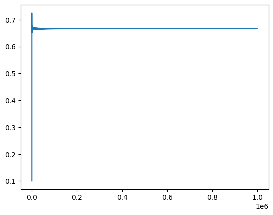

```python
r=3
N=1000000 #je modifie le N en fonction de mes besoins et effectue plusieurs tests pour mieux le choisir

function(N)
```

Cette fois ci on constate que la suite converge vers 0.66.

r = 3.5

```
0.5008939563047393 0.8749972029474383
```

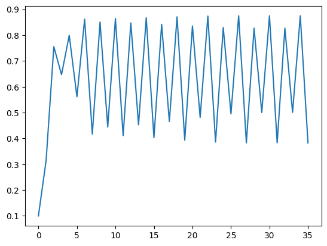

```python
r=3.5
N=35

function(N)
```

Cette fois ci la suite ne converge pas, elle ocsille sur un intervalle (entre 0.4 et 0.9).

r = 4

```
0.07261802811555765 0.26937860043266293
```

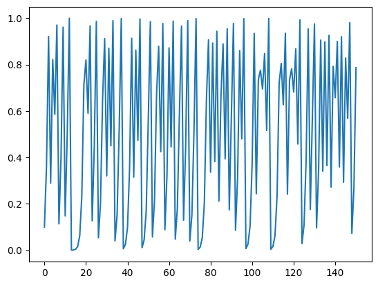

```python
r=4
N=150

function(N)
```

On remarque cette fois aussi que la suite ne converge pas.

### **Diagramme de bifurcation**

On va d'abord créé un tableau avec plusiaur valeur de r comprise entre 2.5 et 4

```python
r=np.linspace(2.5, 4, 300)
```

Puis pour chaque valeur de r on calcule les 1000 premiers termes de la suite et on en garde que les 100 derniers que l'on met dans un tableau en fonction des valeurs de r

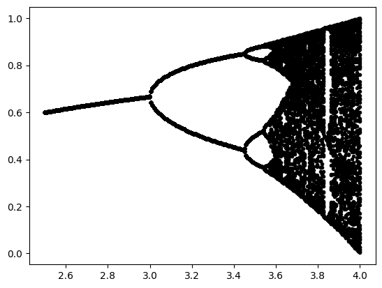

```python
for k in range(len(r)):                 #pour etudier toutes les valeurs de r
    N=1000
    n=100
    j = np.arange(0, N, 1)              #création d'un lableau d'entier allant de 0 à N-1, donc de N valeurs
    x =[0.00001]                        #on créé le tableau x en t metant la valeur x0
    for i in range (N):
        x.append(r[k]*(1-x[i])*x[i])
    x1 = x[901:]                        #extrait les 100 dernières valeurs
    r1 = np.ones(100) * r[k]            # créé un tableau des mêmes dimensions de x1 avec touts les valeurs égales à r afin de pouvoir les mettre dans la fontion plot
    plt.plot(r1, x1, '.', color='black')
```

Tout d'abordn on constate que le diagramme ressemble bien a celui de l'enoncé. Ensuite on constate que pour les premières valeurs de r, il existe une limite finie, puis pour les valeurs intermediaires la suite oscille entre deux valeurs, deux limites, puis quatres limites, enfin pour les dernieres valeurs la suite a de plus en plus de limites. Il existe donc une limite finie unique pour les valeurs de r allant jusqu'à ≈ 3.

À r=2.5, la limite est la meme que trouvée précedement, donc le comportement de la suite ne depend pas de x<sub>0</sub> **mais bien de r**.

### **Exposant de Lyapunov**

Mathématiquement, la distance entre deux solutions va augmenter de manière exponentielle.

On cherche une forme en

$$ e^{t \lambda(r)} $$

La manière de calculer l'exposant $\lambda(r)$ est due à Aleksander Lyapunov (1857-1918). L'expression de $\lambda(r)$ est

$$ \lambda = \lim\limits_{n \rightarrow \infty} \frac{1}{n} \sum_{i=0}^{n-1} \log | f^{\prime} (x_i)| $$

Pour cela nous avons besoin de la fonction f' $$ f(x) = r (1-x) x $$ $$ f'(x)=r (1-2x)$$

On cherche à représenter les valeurs de lambda en fonction de r

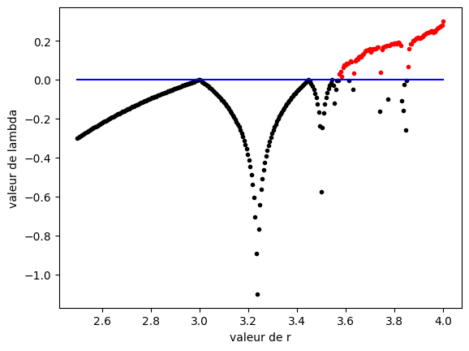

```python
import math
l=[]

for i in range (len(r)):   #permet d'etudier toutes les valeurs de r
    n=10000                 # valeur de n grande pour tendre vers + ∞
    x =[0.1]
    for b in range (n):
        x.append(r[i]*(1-x[b])*x[b]) #permet d'avoir un tableau avec les n premières valurs de la suite
    lo=[]
    for k in range(n):
        v = math.log(abs(r[i]*(1-2*x[k])), 10)
        lo.append(v)    #permet d'avoir un tableau avec les valeurs des log
    l.append(1/n*sum(lo))   #ajoute au tableau l des lamdba la nouvelle valeur
for i in range(len(l)):
    if l[i]<0:
        plt.plot(r[i], l[i],'.', color='black')  #met en noir les lambda inférieurs à 0
    else:
        plt.plot(r[i], l[i],'.', color='r')  #met en rouge les lambda supérieurs à 0

xbleu = [2.5, 4]
ybleu = [0, 0]
plt.xlabel('valeur de r')
plt.ylabel('valeur de lambda')
plt.plot(xbleu, ybleu, color='b') # trace la ligne des labda=0 en bleu
```

En le comparant au diagrame de bifurquation on remarque plusieurs choses:

- tout d'abord lorsque $\lambda$ est negatif (en noir sur le graphique), il y a un nombre fini de limites.
- ensuite, lorsque $\lambda$ ateint ou dépasse 0, il y a une limite en plus( du debut jusqu'à à peu près 3, il n'y a qu'une limite finie. puis entre ≈ 3 et ≈ 3.45, soit après le premier $\lambda$=0 et avant le deuxième $\lambda$=0, il y a deux limites.

### *Conclusion*

L'équation logistique est stable lorsque de $\lambda$ est inferieur à zero car cela nous permet d'avoir des limites finies.